# Practical Machine Learning Course Project

Rahil BA

March 13, 2017

Summary

In this report, 2 different Machine Learning algorithms (Random Forest and Decision Tree) are applied to predict the manner in which 6 individuals do their exercises. They were asked to perform barbell lifts correctly and incorrectly in 5 different ways that were assigned to the “classe” variable. Random Forest is chosen as the best classifier,because it gives the highest accuracy

Load libraries:

```r
library(caret)
library(rpart)
library(randomForest)
library(RCurl)
library(e1071)
```

set the seed

```r
set.seed(1234)
```

Let’s download the data:

```r
trainingURL <- getURL("http://d396qusza40orc.cloudfront.net/predmachlearn/pml-training.csv")
training_CSV  <- read.csv(text = trainingURL, header=TRUE, sep=",", na.strings=c("NA",""))
testingURL <- getURL("https://d396qusza40orc.cloudfront.net/predmachlearn/pml-testing.csv")
testing_CSV  <- read.csv(text = testingURL, header=TRUE, sep=",", na.strings=c("NA",""))
```

Let’s clean the data: I am going to remove the first column that sounds like an index variable since it doesn’t add any value to my prediction model.

```r
training_CSV <- training_CSV[,-1]
Data <- training_CSV
table(Data$classe)
```

```
##
##    A    B    C    D    E
## 5580 3797 3422 3216 3607
```

with in these 160 variables, there are some variables that have NA values and are not related to accelerometers on the belt, forearm, arm, and dumbbell.So, I am going to removed theose columns that have about 70% of NAs. Also,I will remove those variables that are not necessary to fit the model like “time” variables.They have to be removed from test data set as well.

```r
Data <- Data[,-c(1:6)] # remove time variables
sum((colSums(!is.na(Data[,-ncol(Data)])) < 0.7*nrow(Data))) # number of columns with less than 70% of data
```

```
## [1] 100
```

```r
Keep <- c((colSums(!is.na(Data[,-ncol(Data)])) >= 0.7*nrow(Data)))
Data  <-  Data[,Keep]
dim(Data)
```

```
## [1] 19622    53
```

there are about 52 predictors and “classe” variable. Multicollinearity: I calculated the correlations among pairs of predictors. Those from a pair that are highly correlated can be predicted with the other one. Multicollinearity doesnt cause a problem while fitting nonlinear models like Random Forest and Decisin Trees.But, I prefered to have less predictors in my model. Let’s find the correlation matrix:

```r
corrMatrix <- cor(na.omit(Data[sapply(Data, is.numeric)]))
```

Lets’s plot the correlations. There are some correlation values that are values that considered as high (>.9). So, I am going to drop those predictors.

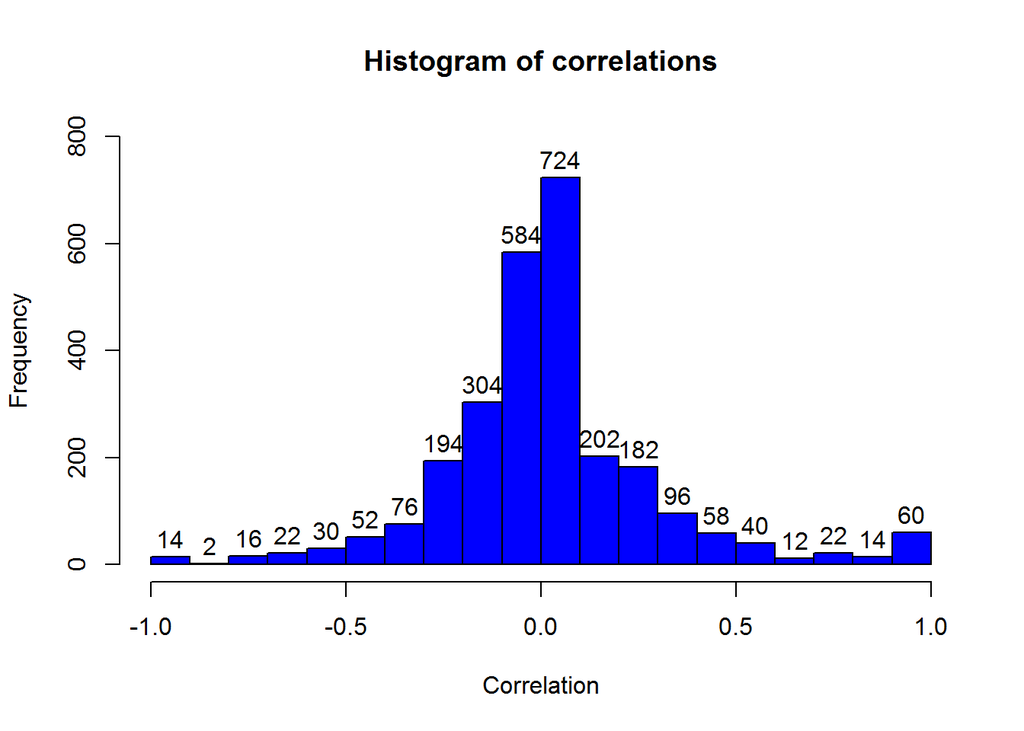

```r
hist(corrMatrix,main="Histogram of correlations",xlab="Correlation",ylim = c(0,800),breaks=15,right=TRUE,col="blue",labels=TRUE)
```

```r
highCorr <- findCorrelation(corrMatrix, cutoff = .90, verbose = T)
```

```
## Compare row 10  and column  1 with corr  0.992
##   Means:  0.27 vs 0.168 so flagging column 10
## Compare row 1  and column  9 with corr  0.925
##   Means:  0.25 vs 0.164 so flagging column 1
## Compare row 9  and column  4 with corr  0.928
##   Means:  0.233 vs 0.161 so flagging column 9
## Compare row 8  and column  2 with corr  0.966
##   Means:  0.245 vs 0.157 so flagging column 8
## Compare row 19  and column  18 with corr  0.918
##   Means:  0.091 vs 0.158 so flagging column 18
## Compare row 46  and column  31 with corr  0.914
##   Means:  0.101 vs 0.161 so flagging column 31
## Compare row 46  and column  33 with corr  0.933
##   Means:  0.083 vs 0.164 so flagging column 33
## All correlations <= 0.9
```

```r
Final_Data <- Data[,-highCorr]
```

Data Partition: Partition Data set to “training”" and “validation”" data sets. About 60 percent of data set is considered as training set.

```r
inTrain <- createDataPartition(Final_Data$classe, p=0.60, list=FALSE)
training <- Final_Data[inTrain,]
validating <- Final_Data[-inTrain,]
dim(training)
```

```
## [1] 11776    46
```

```r
dim(validating)
```

```
## [1] 7846   46
```

Modeling: In the section of this report, I am going to fit 2 classifiers to predict the “classe”" in the test data set : Random Forest and Decision Tree.Then, I will evaluate which have a better performance based on the accuracy. 1) Random Forest let’s fit RF model and getting the k folds cross validation. In this case I going to set k=4.

```r
rfFit <- train(classe ~ ., method = "rf", data = training, importance = T, trControl = trainControl(method = "cv", number = 4))
Pred_RF <- predict(rfFit, newdata=validating)
# Check model performance by using confusion matrix
confusionMatrix(Pred_RF,validating$classe)
```

```
## Confusion Matrix and Statistics
##
##           Reference
## Prediction    A    B    C    D    E
##          A 2230   17    0    0    0
##          B    1 1495   14    1    0
##          C    1    6 1348   18    2
##          D    0    0    6 1265    4
##          E    0    0    0    2 1436
##
## Overall Statistics
##
##                Accuracy : 0.9908
##                  95% CI : (0.9885, 0.9928)
##     No Information Rate : 0.2845
##     P-Value [Acc > NIR] : < 2.2e-16
##
##                   Kappa : 0.9884
##  Mcnemar's Test P-Value : NA
##
## Statistics by Class:
##
##                      Class: A Class: B Class: C Class: D Class: E
## Sensitivity            0.9991   0.9848   0.9854   0.9837   0.9958
## Specificity            0.9970   0.9975   0.9958   0.9985   0.9997
## Pos Pred Value         0.9924   0.9894   0.9804   0.9922   0.9986
## Neg Pred Value         0.9996   0.9964   0.9969   0.9968   0.9991
## Prevalence             0.2845   0.1935   0.1744   0.1639   0.1838
## Detection Rate         0.2842   0.1905   0.1718   0.1612   0.1830
## Detection Prevalence   0.2864   0.1926   0.1752   0.1625   0.1833
## Balanced Accuracy      0.9980   0.9912   0.9906   0.9911   0.9978
```

2. Decision tree

```r
dtFit <- train(classe ~ .,trControl=trainControl(method = "cv", number = 4),method="rpart",data=training)
Pred_DT <- predict(dtFit, newdata=validating)
# Check model performance by using confusion matrix
confusionMatrix(Pred_DT,validating$classe)
```

```
## Confusion Matrix and Statistics
##
##           Reference
## Prediction    A    B    C    D    E
##          A 2031  638  643  488  314
##          B   44  505   49  232  281
##          C  126  336  542  144  316
##          D   29   39  133  303   48
##          E    2    0    1  119  483
##
## Overall Statistics
##
##                Accuracy : 0.4925
##                  95% CI : (0.4814, 0.5036)
##     No Information Rate : 0.2845
##     P-Value [Acc > NIR] : < 2.2e-16
##
##                   Kappa : 0.3368
##  Mcnemar's Test P-Value : < 2.2e-16
##
## Statistics by Class:
##
##                      Class: A Class: B Class: C Class: D Class: E
## Sensitivity            0.9099  0.33267  0.39620  0.23561  0.33495
## Specificity            0.6290  0.90424  0.85767  0.96204  0.98095
## Pos Pred Value         0.4937  0.45455  0.37022  0.54891  0.79835
## Neg Pred Value         0.9461  0.84959  0.87057  0.86523  0.86756
## Prevalence             0.2845  0.19347  0.17436  0.16391  0.18379
## Detection Rate         0.2589  0.06436  0.06908  0.03862  0.06156
## Detection Prevalence   0.5243  0.14160  0.18659  0.07035  0.07711
## Balanced Accuracy      0.7695  0.61845  0.62694  0.59883  0.65795
```

Conclusion: Random Forest has higher accuracy.So,I will apply RF on my test data set to predict “Classe”. Model Test data set: Finally, I am going to predict the new values in test data set.First, I apply the same data preparation operations on test data set.

```r
dim(testing_CSV)
```

```
## [1]  20 160
```

```r
testing_CSV <- testing_CSV [,-1] # Remove the first column that represents a ID Row
testing <- testing_CSV[,-c(1:6)]
testing <- testing[ , Keep]
testing <- testing[,-highCorr]
dim(testing)
```

```
## [1] 20 46
```

```r
predict <- predict(rfFit, newdata=testing)
print(predict)
```

```
##  [1] B A B A A E D B A A B C B A E E A B B B
## Levels: A B C D E
```

The following function to create the files to answers the Prediction Assignment Submission.

```r
write_files <- function(x) {
  n <- length(x)
  for (i in 1:n) {
    filename <- paste0("problem_id", i, ".txt")
    write.table(x[i], file=filename, quote=FALSE, row.names=FALSE,col.names=FALSE)
  }
}
write_files(predict)
```